# KidDraw-Analysis1

Bria Long

11/24/2017

## Load data and do basic preprocessing.

```r
## Read in data outputs from python - stroke numbers, intensity, bounding boc, etc.
# get rid of drwaings without age - these were when we were testing the interface.
# make new variable name with image name for joining with recognition data
d <- read_csv("preprocessed_data/museumdraw_E1c_imageData.csv") %>%
  select(-X1) %>%
  filter(!is.na(age)) %>%
  mutate(imNameShort = paste0(category, '_sketch', '_', age,'_', session_id, '.png'))
## Read in data outputs from turk data - true/false recognition with 21AFC
r <- read.csv("preprocessed_data/museumdraw_E1c_recognitionData.csv") %>%
  as.tibble()

## check we have the right lengths
assert_that(length(d$session_id)==length(unique(r$imageName)))
```

```
## [1] TRUE
```

## Take a look at the raw rating data as a sanity check

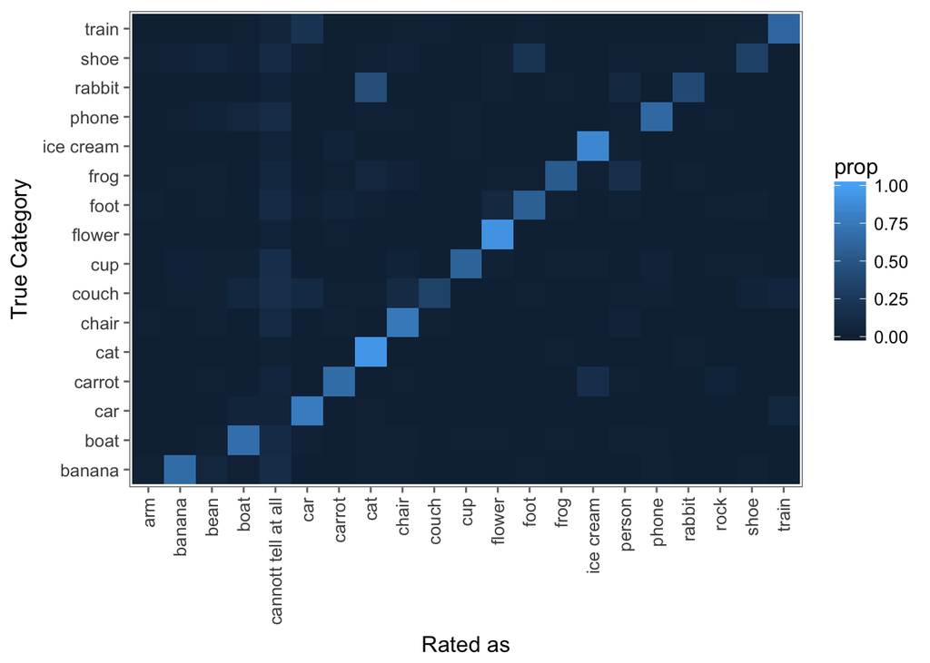

```r
ratingConfusions <- r %>%
  group_by(category, rating)  %>%
  summarize(number = n()) %>%
  group_by(category) %>%
  mutate(prop = number / sum(number)) %>%
  complete(rating, fill = list(prop = 0))


ggplot(ratingConfusions,
       aes(x = rating, y = category, fill = prop)) +
  geom_tile() +
  ylab("True Category") +
  xlab("Rated as") +
  scale_fill_gradient(limits = c(0, 1)) +
  theme(axis.text.x = element_text(angle = 90, hjust = 1, vjust = .5))
```

## Preprocess data and join datasets

```r
# add special column for when people selected "can't tell at all" during ratings; not separated out in current analyses
r$cantTell=(r$rating=="cannott tell at all")

## Get the percent recognized for each drawing
corbyItem <- r %>%
  group_by(imNameShort) %>%
  summarize(meanCorrect = mean(correct),
            propCantTell = mean(cantTell))

## Joint the two datasets together
joint=left_join(d,corbyItem) %>%
  mutate(session_id = factor(session_id),
         category = factor(category))
## for use below with glmer analyses
joinedRatings <- left_join(r,d)
```

## Basic descriptives

Number of drawings: 286

Number of drawers: 41

Average age of drawers: 6.9

Drawings by category:

```r
joint %>%
  group_by(category) %>%
  summarize(count = n()) %>%
  kable()
```

| category | count |
| --- | --- |
| banana | 17 |
| boat | 18 |
| car | 18 |
| carrot | 17 |
| cat | 16 |
| chair | 20 |
| couch | 16 |
| cup | 17 |
| flower | 20 |
| foot | 16 |
| frog | 15 |
| ice cream | 17 |
| phone | 18 |
| rabbit | 21 |
| shoe | 17 |
| train | 23 |

Drawings by age

```r
ageCorrOut<-joint %>%
  group_by(age) %>%
  summarize(count = n(),
            meanCorrect = mean(meanCorrect),
            propCantTell = mean(propCantTell))

kable(ageCorrOut,digits = 2)
```

| age | count | meanCorrect | propCantTell |
| --- | --- | --- | --- |
| 4 | 17 | 0.14 | 0.29 |
| 5 | 42 | 0.45 | 0.15 |
| 6 | 56 | 0.70 | 0.07 |
| 7 | 32 | 0.72 | 0.06 |
| 8 | 87 | 0.66 | 0.08 |
| 9 | 8 | 0.76 | 0.03 |
| 10 | 44 | 0.85 | 0.03 |

# Exploratory plots

## How much do num_strokes / intensity / duration covary with eachother?

In all of the following plots, one point = one drawing.

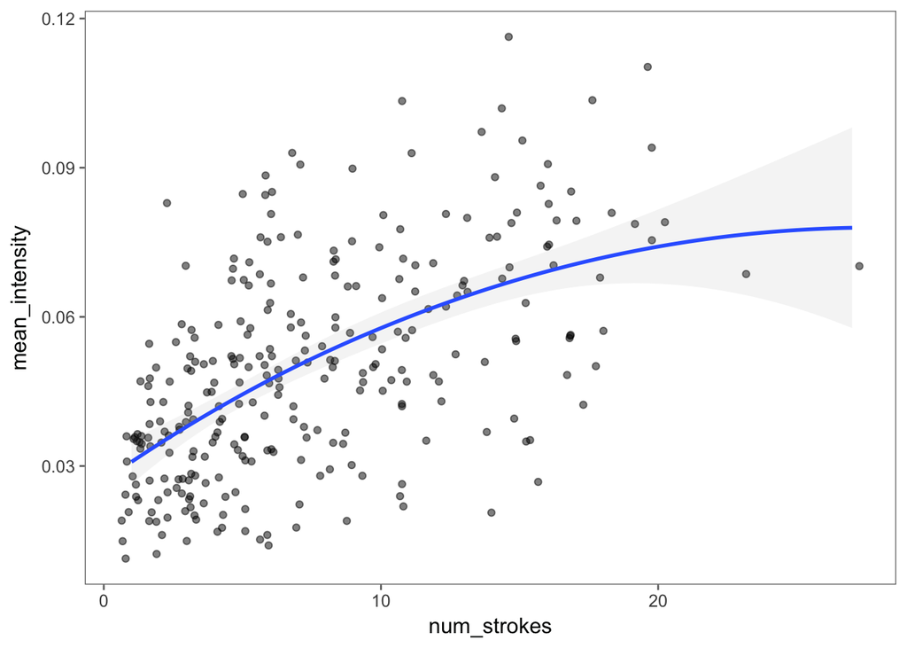

```r
ggplot(d, aes(x = num_strokes, y = mean_intensity)) +
  geom_jitter(alpha=.5) +
  geom_smooth(method="loess", span=2, alpha=.1)
```

Strokes scale almost completely linearly with time.

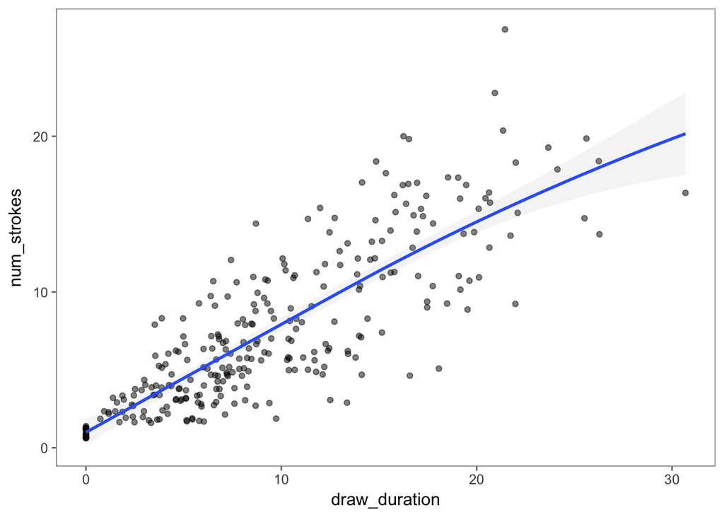

```r
ggplot(d, aes(x = draw_duration, y = num_strokes)) +
  geom_jitter(alpha=.5) +
  geom_smooth(method="loess", span=2, alpha=.1)
```

## Are darker drawings better recognized?

Interesting - probably somewhat up to a point. Last points are creating a big tail on the loess function but probably more ink = more information = better recognized

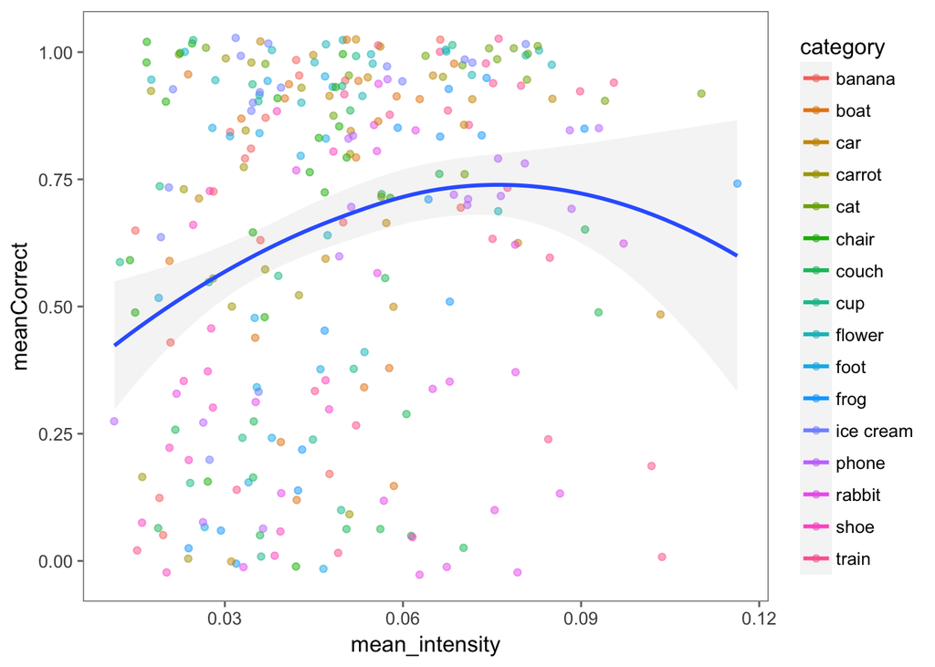

```r
ggplot(joint, aes(mean_intensity, meanCorrect, color=category)) +
  geom_jitter(alpha=.5) +
  geom_smooth(aes(group = 1), method="loess", span=2, alpha=.1)
```

## Are drawings with more strokes better recognized?

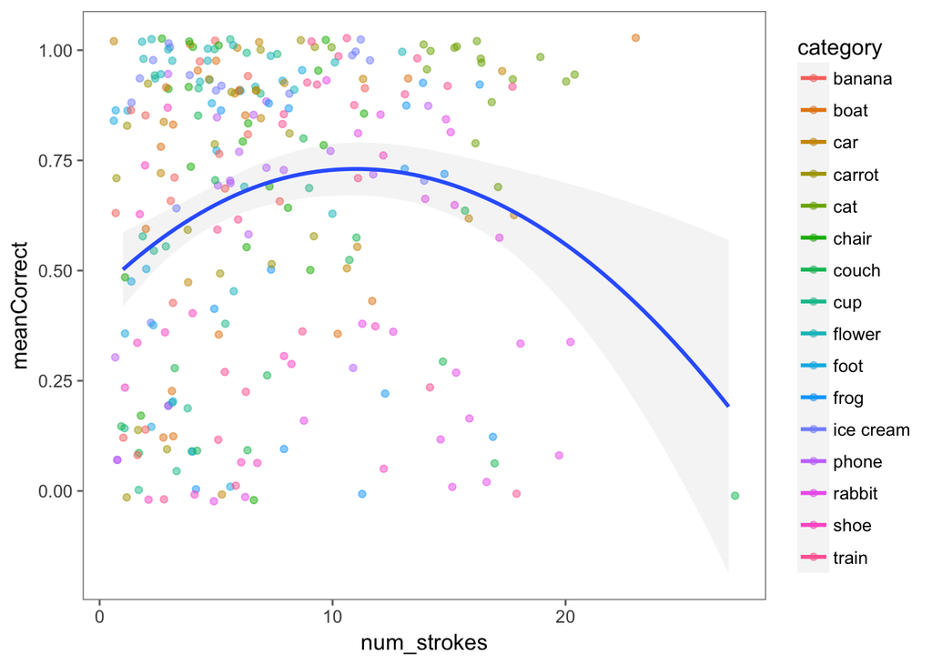

```r
ggplot(joint, aes(num_strokes, meanCorrect, color=category)) +
  geom_jitter(alpha=.5) +
  geom_smooth(aes(group = 1), method="loess",span=2, alpha=.1)
```

## Are drawings that take longer better recognized?

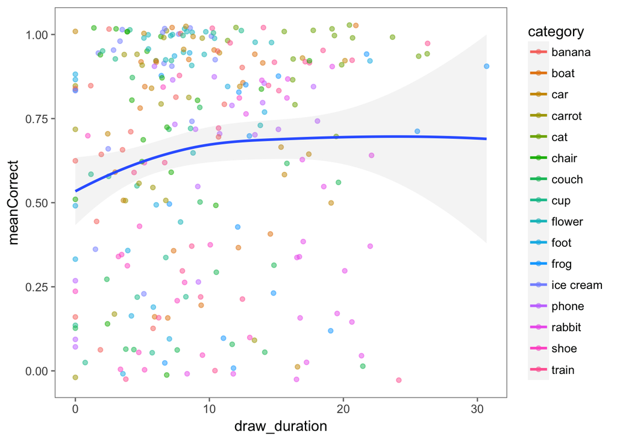

```r
ggplot(joint, aes(draw_duration, meanCorrect, color=category)) +
  geom_jitter(alpha=.5) +
  geom_smooth(aes(group = 1), method="loess",span=2, alpha=.1)
```

## Are drawings better recognized with age?

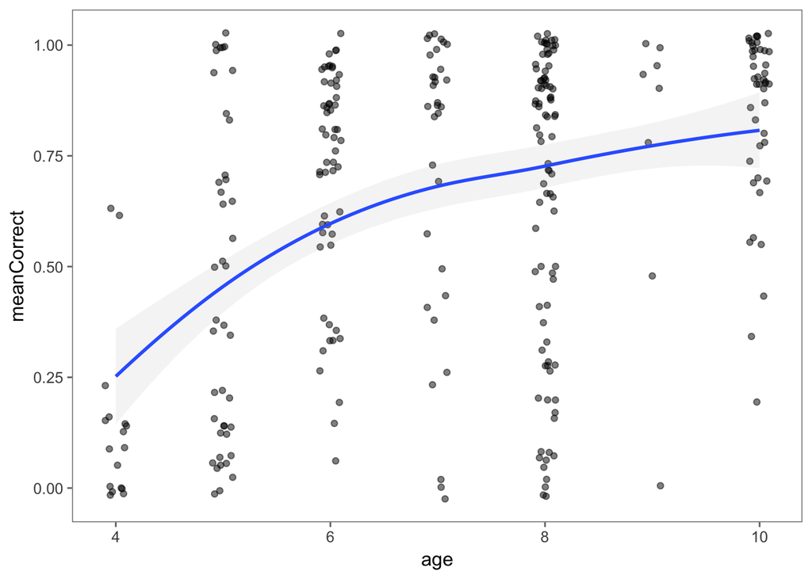

```r
ggplot(joint, aes(age, meanCorrect)) +
  geom_jitter(alpha=.5, width = .1) +
  geom_smooth(method="loess",span=2, alpha=.1)
```

## How does this trend break down by catergory?

Some items show a stronger trend than others but overall looks good

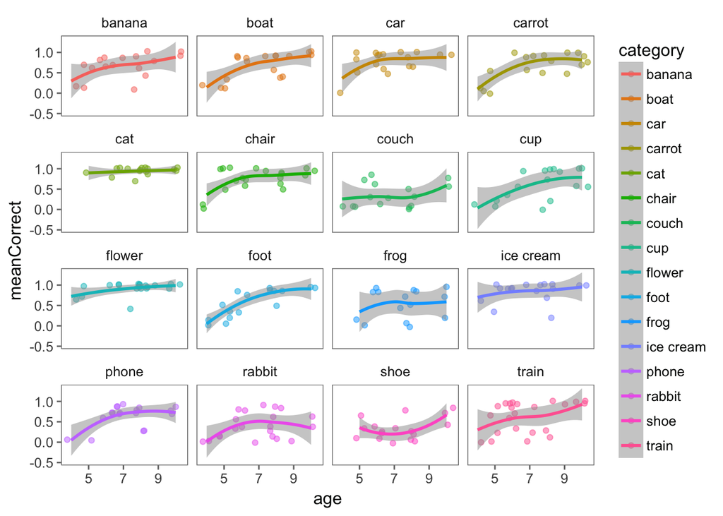

```r
ggplot(joint, aes(age, meanCorrect, color=category)) +
  geom_jitter(alpha=.5) +
  geom_smooth(method="loess",span=2, alpha=.5) +
  facet_wrap(~category)
```

## Which items are easiest and hardest?

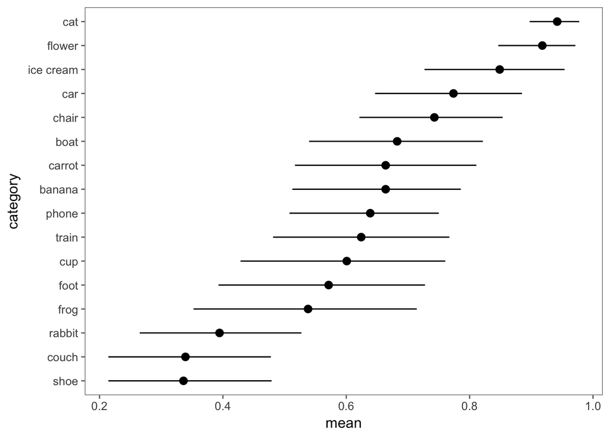

```r
ms <- joint %>%
  group_by(category) %>%
  multi_boot_standard(col = "meanCorrect")  %>%
  ungroup %>%
  mutate(category = fct_reorder(category, mean))

ggplot(ms, aes(x = category, y = mean)) +
  geom_pointrange(aes(ymin = ci_lower, ymax = ci_upper)) +
  coord_flip()
```

## Across ages?

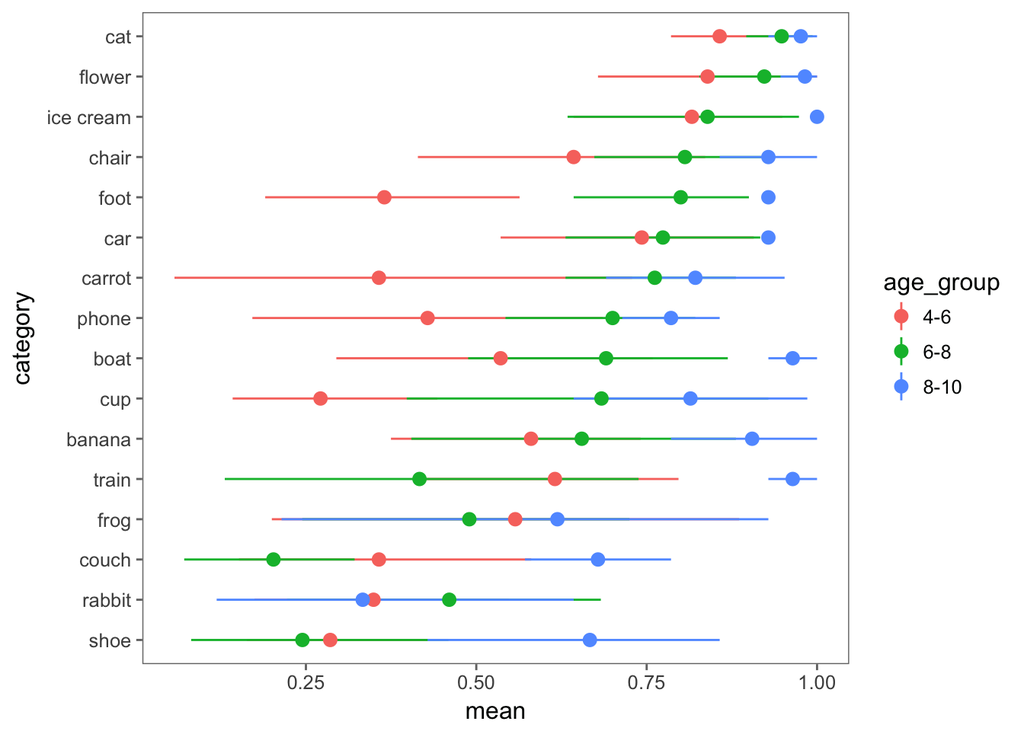

```r
ms <- joint %>%
  mutate(age_group = cut(age, c(3.9, 6, 8, 10.1), labels = c("4-6","6-8","8-10"))) %>%
  group_by(category, age_group) %>%
  multi_boot_standard(col = "meanCorrect")  %>%
  ungroup %>%
  mutate(category = fct_reorder(category, mean))

ggplot(ms, aes(x = category, y = mean, col = age_group)) +
  geom_pointrange(aes(ymin = ci_lower, ymax = ci_upper)) +
  coord_flip()
```

## How much variance is there per participant (i.e., per child drawer?)

Looks like there are some kids that are very bad or very good at drawing, but there is also a fair number of kids with wide distributions

```r
ms <- joint %>%
  group_by(session_id) %>%
  summarise(sd = sd(meanCorrect),
            mean = mean(meanCorrect))

joint <- left_join(joint, ms) %>%
  mutate(session_id = fct_reorder(session_id, mean, .desc=TRUE))
```

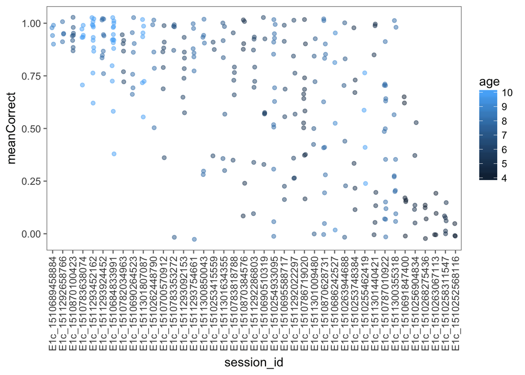

```r
ggplot(joint, aes(x = session_id, y = meanCorrect, col = age)) +
  geom_jitter(width = .1, alpha = .5) +
  theme(axis.text.x = element_text(angle = 90, hjust = 1, vjust = .5))
```

## Inferential statistics: Does recogizability of drawings increase with age?

```r
mod <- glmer(correct ~ age + (1 | session_id) + (1 | category),
      data = joinedRatings,
      family = "binomial")

kable(summary(mod)$coef, digits = 3)
```

|  | Estimate | Std. Error | z value | Pr(>\|z\|) |
| --- | --- | --- | --- | --- |
| (Intercept) | -2.977 | 0.755 | -3.941 | 0 |
| age | 0.538 | 0.099 | 5.427 | 0 |

Now add some predictors, including number of strokes, draw duration, and avg intensity (e.g., amount of ink). Standardize predictors for comparability.

```r
mod_covariates <- glmer(correct ~ scale(age) +
                          scale(draw_duration) +
                          scale(mean_intensity) +
                          scale(num_strokes) +
                        (1|session_id) +
                        (1 | category),
      data = joinedRatings,
      family = "binomial")
modelOut=summary(mod_covariates)
kable(summary(mod_covariates)$coef, digits = 3)
```

|  | Estimate | Std. Error | z value | Pr(>\|z\|) |
| --- | --- | --- | --- | --- |
| (Intercept) | 0.861 | 0.321 | 2.680 | 0.007 |
| scale(age) | 0.956 | 0.174 | 5.497 | 0.000 |
| scale(draw_duration) | 0.338 | 0.109 | 3.105 | 0.002 |
| scale(mean_intensity) | 0.014 | 0.080 | 0.179 | 0.858 |
| scale(num_strokes) | -0.289 | 0.098 | -2.959 | 0.003 |

Poke around with interactions with age. Critical generalization is that the age increase still holds even controlling these factors, and there is no interaction. Could do this model a bunch of different ways, this is just one possibility.

```r
mod_covariates_age <- glmer(correct ~ (scale(age) +
                          scale(draw_duration) +
                          scale(num_strokes))^2 +
                        (1|session_id) +
                        (1|category),
      data = joinedRatings,
      family = "binomial")
kable(summary(mod_covariates_age)$coef, digits = 3)
```

|  | Estimate | Std. Error | z value | Pr(>\|z\|) |
| --- | --- | --- | --- | --- |
| (Intercept) | 1.005 | 0.325 | 3.088 | 0.002 |
| scale(age) | 0.939 | 0.176 | 5.350 | 0.000 |
| scale(draw_duration) | 0.277 | 0.105 | 2.629 | 0.009 |
| scale(num_strokes) | -0.169 | 0.104 | -1.629 | 0.103 |
| scale(age):scale(draw_duration) | -0.086 | 0.106 | -0.807 | 0.419 |
| scale(age):scale(num_strokes) | 0.016 | 0.102 | 0.152 | 0.879 |
| scale(draw_duration):scale(num_strokes) | -0.151 | 0.046 | -3.237 | 0.001 |

One other try, removing interaction between draw_duration & num_strokes

```r
mod_covariates_age_v2 <- glmer(correct ~ scale(age) +
                          scale(draw_duration) +
                          scale(num_strokes) +
                          scale(age)*scale(draw_duration) +
                          scale(age)*scale(num_strokes) +
                        (1|session_id) +
                        (1|category),
      data = joinedRatings,
      family = "binomial")

kable(summary(mod_covariates_age_v2)$coef, digits = 3)
```

[output not shown]

“Drawings as a window into the development of object category representations”

Drawing is a powerful tool for communicating concepts in visual form — a few well-placed strokes can convey the identity of a person, object, or scene. Prior work has found that deep neural network models of the ventral stream trained purely on photographs can also recognize drawings by nonexpert adults, reflecting concordance in abstract representations of object categories in drawings and photos at higher layers in these models (Fan, Yamins, & Turk-Browne, 2015). How do ordinary people become so effective at producing recognizable drawings? Here we examine the trajectory of this learning during childhood. Children (N = 41, *M* = 6.9 years, range 4-10 years) participated in an iPad-based drawing game where they were prompted with a verbal cue to draw one of sixteen familiar objects (e.g., “Can you draw a cup?”). Children drew each object category for 30 seconds, after which they were prompted to either make another drawing or to stop drawing altogether. Afterwards, a group of naive adults (N = 14) guessed the identity of each drawn object (286 drawings). A generalized logistic mixed-effect model revealed that the recognizability of drawings increased reliably with age (b = 0.96, SE = 0.17, Z = 5.5), accounting for variation across object categories and individual children (% drawings recognized; chance = 4.8%; $M_{4yrs}$ = 14%, $M_{5yrs}$ = 45%, $M_{6yrs}$ = 70%, $M_{7yrs}$ = 72%, $M_{8yrs}$ = 66%, $M_{9yrs}$ = 76%, $M_{10yrs}$ = 85%). Further, this relationship persisted when controlling for several low-level covariates — the amount of time spent drawing, the number of strokes, and total ink used. These results suggest that the capacity to quickly produce graphical representations that communicate object category information is highly developed by middle childhood. More broadly, these findings point to visual production tasks as a promising avenue for examining the development of object category representations.

Word Limit: 300 words (currently at 301 words)